# Canadian Ambient Air Quality:

Pollution Monitoring and Indicator Analysis

# 1 Introduction

Our statistical analysis evaluates particular matter at 2.5 microns air quality monitoring measurement which were monitored collectively by the province and territories of Canada and reported by Environment Canada, in the Environment Canada Data Catalog. .

## 1.1 Motivation

Ambient pollution in both high population and rural areas is estimated to cause 4.2 million premature deaths worldwide per year in 2016. Exposure to fine particulate matter ( 2.5 microns or less in diameter ) causes cardiovascular and respiratory disease, and cancers (NewsRoom).

## 1.2 Structure of report

Each section provides,

- Brief data set description: raw and wrangled states.
- Exploratory Data Analysis (EDA): to support the guiding question.
- Temporal or Location based hypothesis testing.
- Discussion and conclusion of the findings.

## 1.3 Source of Data

The Information Provider grants a worldwide, royalty-free, perpetual, non-exclusive license to use the Information, including for commercial purposes for any lawful purpose. The data license can be found at [Data License](https://donnees.ec.gc.ca/data/license-en.txt) and states that we “are encouraged to use the Information that is available under this license with only a few conditions.”

Contains information licensed under the Open Government Licence – Canada.

## 1.4 The Dataset

### 1.4.1 Raw Dataset Overview

PM2.5 Raw data set is provided as a yearly chunk of Continuous hourly monitoring data starting from the year “1990 to 2020”. For the Exploratory Data Analysis, due to the huge size of the files, we randomly picked two cities (Richmond and Halifax) that are near Mercury and PH concentration observation sites and only limited the sample provided from 2010 to 2020. Please refer to the following file for the sample taken for this analysis.

```r
df.1 = read_csv("./PM25_files/PM25(2010-2020).csv")
head(df.1,2)
```

| Pollutant | City | P.T | Date | Hour | PM2.5µg_m3 | Year | Month | Day |
| --- | --- | --- | --- | --- | --- | --- | --- | --- |
| PM2.5 | Halifax | NS | 2010-01-01 | H13 | 4.5833 | 2010 | 1 | 1 |
| PM2.5 | Halifax | NS | 2010-01-02 | H15 | 3.9583 | 2010 | 1 | 2 |

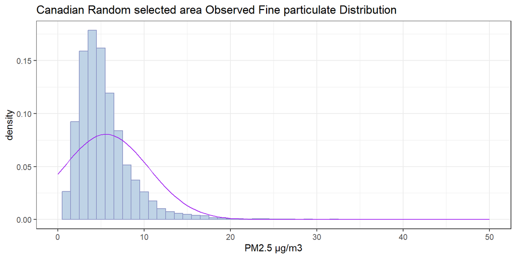

```r
data.mean = favstats(~PM2.5µg_m3, data = df.1)$mean
data.sd = favstats(~PM2.5µg_m3, data = df.1)$sd
eda1 = ggplot(select(df.1, City, PM2.5µg_m3), aes(x =PM2.5µg_m3))+geom_histogram(aes(y = ..density..),binwidth = 1,na.rm = TRUE, color = manual.colors[3], fill= manual.colors[1])+ theme_bw()  + xlab("PM2.5 µg/m3")+ggtitle("Canadian Random selected area Observed Fine particulate Distribution")+ylab("density")+xlim(0,50)
grid.arrange(eda1 + stat_function(fun = dnorm, args = list(mean = data.mean, sd = data.sd), color = "purple", size = 0.5), nrow=1)
```

From the graph above, we can see the data is not normally distributed and is highly right-skewed. Please note for the observation; we have trimmed the x-axis to limit to 50 from 150. To verify if there are rare outliers that may cause this issue, we have continued to explore the data using scatter and box plots, as shown below.

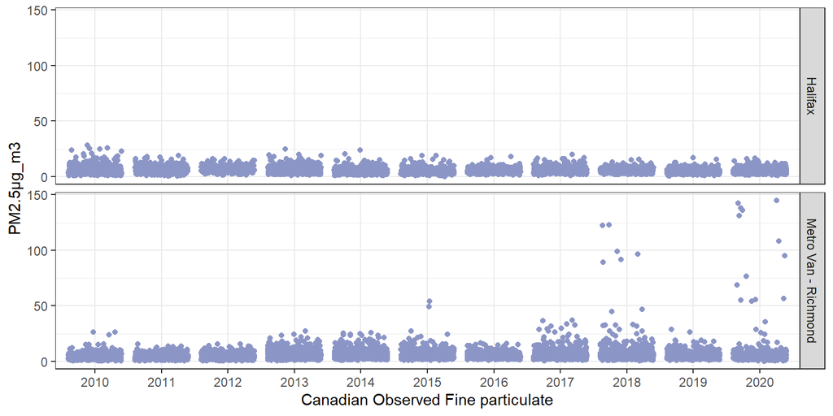

```r
ggplot(data = na.omit(df.1), aes(x = as.factor(Year) , y = PM2.5µg_m3))+geom_point(position = "jitter",na.rm = TRUE,color = manual.colors[3], fill= manual.colors[1])+ theme_bw() + xlab("Canadian Observed Fine particulate") + facet_grid(row = "City")
```

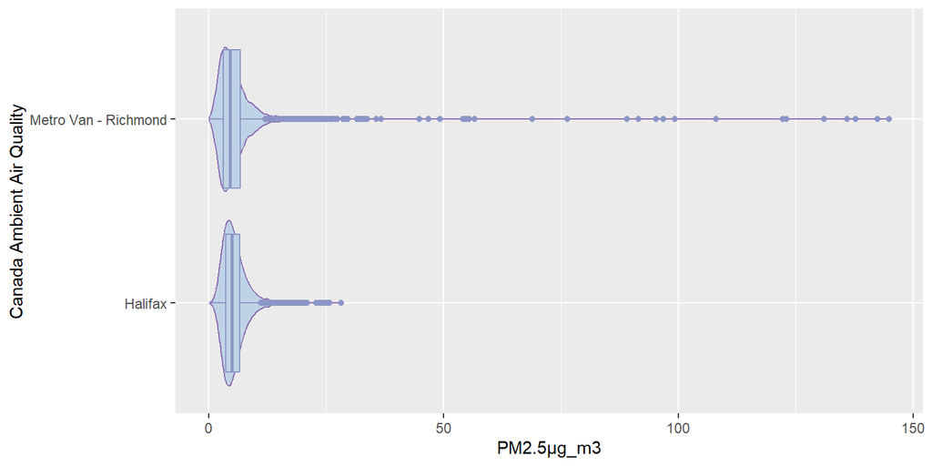

```r
ggplot(data = na.omit(filter(df.1)), aes(x =PM2.5µg_m3,y=City))+geom_violin(na.rm=TRUE, color = manual.colors[4], fill= manual.colors[1] ) + geom_boxplot(na.rm=TRUE,color = manual.colors[3], fill= manual.colors[1]) + ylab("Canada Ambient Air Quality")
```

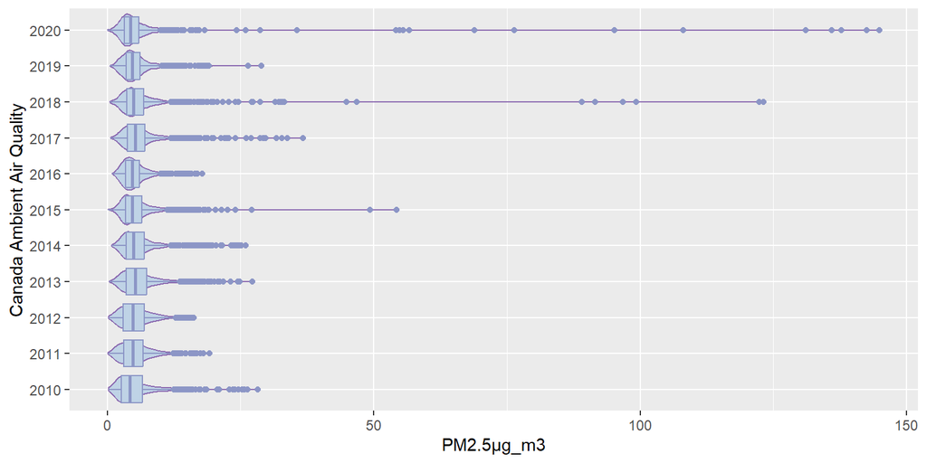

```r
ggplot(data = na.omit(filter(df.1)), aes(x =PM2.5µg_m3,y=as.factor(Year)))+geom_violin(na.rm=TRUE, color = manual.colors[4], fill= manual.colors[1] ) + geom_boxplot(na.rm=TRUE,color = manual.colors[3], fill= manual.colors[1]) + ylab("Canada Ambient Air Quality")
```

From the plots above, we can see Richmond has a lot of outliers from the year 2015 and later. The box plot does not show any difference between these two cities’ exposure to Fine particulate concentrations of PM2.5 pollutants. So, we try to continue to see if the data transformation can make this observed concentration normalized. We have chosen the log transformation to correct these outliers.

### 1.4.2 Data wrangling and performing the log transformation:

Before performing the data transformation, we performed cleaning and wrangled the data to make the data ready to start the statistical analysis. Also, remove the NA from the sample

```r
df.1$Year <- as.factor(df.1$Year)
df.1$Month <- as.factor(df.1$Month)
df.1$Day <- as.factor(df.1$Day)
df.1 <- na.omit(df.1)
df.1 = df.1 %>%
  mutate(Season = cut(as.numeric(Month), breaks=c(5,8,11,12,2), labels = c("Spring ", "Summer", "Fall", "Winter")),
         Monthly = cut(as.numeric(Month), breaks=c(0,1,2,3,4,5,6,7,8,9,10,11,12), labels = c("January", "February", "March", "April", "May", "June", "July", "August", "September", "October", "November", "December")),
         Air_Quality = cut(PM2.5µg_m3, breaks=c(-5,12,35.4,500.4), labels = c("Good", "Moderate", "Unhealthy")),
         Air_Quality_Index = cut(PM2.5µg_m3, breaks=c(-5,12,35.4,55.4,150.4,250.4), labels = c("0-12", "12-35.4", "35.5-55.4", "55.5-150.4","150.5-250.4,250.5-500.4")))

df.1["Season"][is.na(df.1["Season"])] <- "Winter"
df.1 <- df.1 %>%
  mutate(PM2.5µg_m3_tran = log(PM2.5µg_m3))
head(df.1,2)
```

| Pollutant | City | P.T | Date | Hour | PM2.5µg_m3 | Year | Month | Day | Season | Monthly | Air_Quality | Air_Quality_Index | PM2.5µg_m3_tran |
| --- | --- | --- | --- | --- | --- | --- | --- | --- | --- | --- | --- | --- | --- |
| PM2.5 | Halifax | NS | 2010-01-01 | H13 | 4.5833 | 2010 | 1 | 1 | Winter | January | Good | 0-12 | 1.522419 |
| PM2.5 | Halifax | NS | 2010-01-02 | H15 | 3.9583 | 2010 | 1 | 2 | Winter | January | Good | 0-12 | 1.375815 |

We have added the extra variable that is required for the analysis. Information on the PM2.5 standard is from the reference ([www.blissair.com](https://blissair.com/what-is-pm-2-5.htm)). After the data transformation, we have done another normality distribution test, and the results are as shown below:

## 1.5 Data transformation and Condition Validation

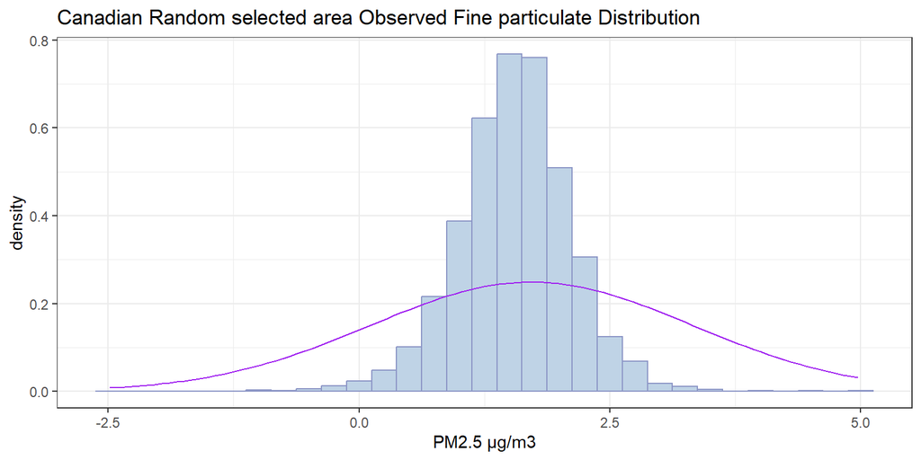

```r
eda2 =  ggplot(na.omit(select(df.1, City, PM2.5µg_m3_tran)), aes(x =PM2.5µg_m3_tran))+geom_histogram(aes(y = ..density..),binwidth = 0.25,na.rm = TRUE, color = manual.colors[3], fill= manual.colors[1])+ theme_bw()  + xlab("PM2.5 µg/m3")+ggtitle("Canadian Random selected area Observed Fine particulate Distribution")+ylab("density")
grid.arrange(eda2 + stat_function(fun = dnorm, args = list(mean = log(data.mean), sd = log(data.sd)), color = "purple", size = 0.5), nrow=1)
```

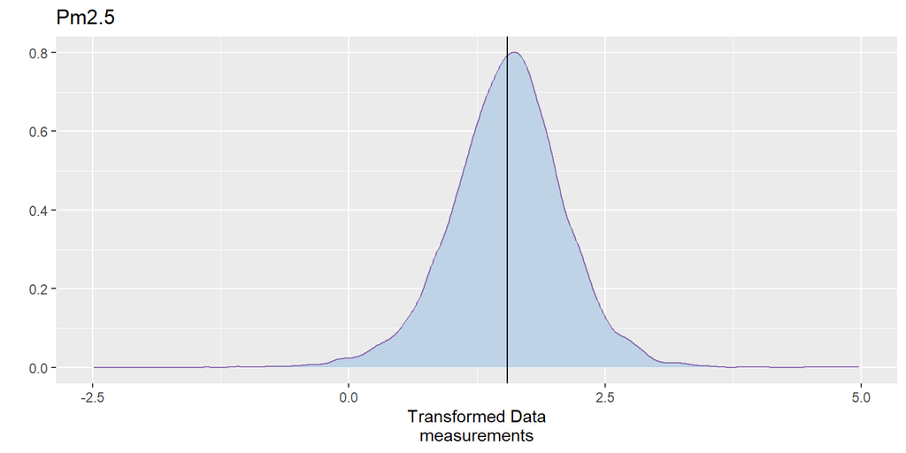

```r
ggplot(data =df.1, aes(x= PM2.5µg_m3_tran))+geom_density(color = manual.colors[4], fill= manual.colors[1])+xlab("Transformed Data
measurements")+ylab("")+ggtitle("Pm2.5")+geom_vline(xintercept = favstats(~PM2.5µg_m3_tran, data = df.1)$mean)
```

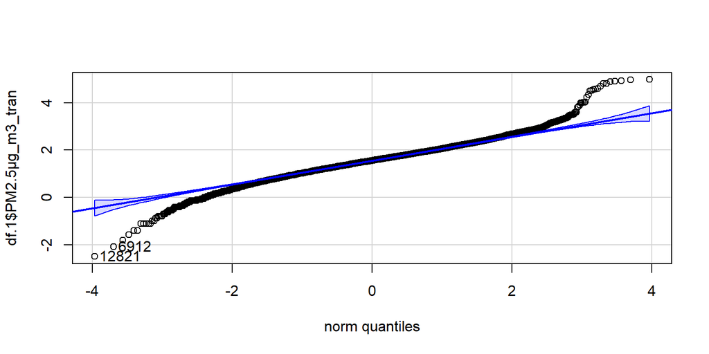

```
## [1] 12821  6912
```

```r
qqPlot(df.1$PM2.5µg_m3_tran)
```

## 1.6 Exploration Data Analysis

### 1.6.1 1.Difference in the PM2.5 pollutant concentration in both the cities.

#### 1.6.1.1 2.Yearly concentration for the selected sample.

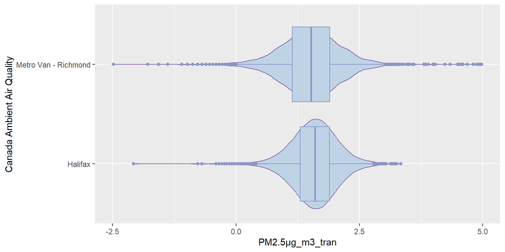

```r
ggplot(data = na.omit(filter(df.1)), aes(x =PM2.5µg_m3_tran,y=City))+geom_violin(na.rm=TRUE, color = manual.colors[4], fill= manual.colors[1] ) + geom_boxplot(na.rm=TRUE,color = manual.colors[3], fill= manual.colors[1]) + ylab("Canada Ambient Air Quality")
```

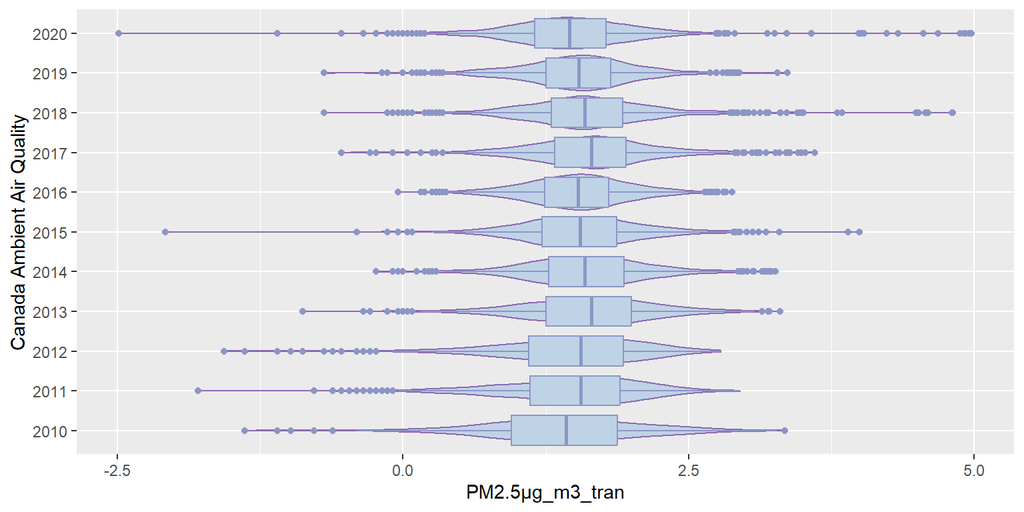

```r
ggplot(data = na.omit(filter(df.1)), aes(x =PM2.5µg_m3_tran,y=as.factor(Year)))+geom_violin(na.rm=TRUE, color = manual.colors[4], fill= manual.colors[1] ) + geom_boxplot(na.rm=TRUE,color = manual.colors[3], fill= manual.colors[1]) + ylab("Canada Ambient Air Quality")
```

#### 1.6.1.2 Exploring distribution separately of both the cities:

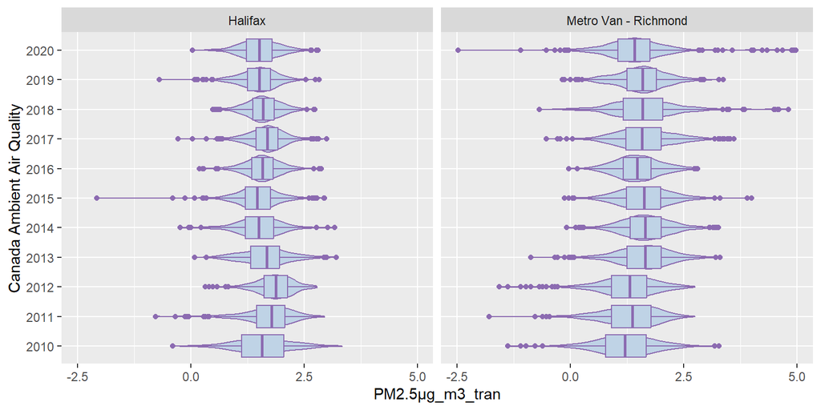

```r
ggplot(data = na.omit(filter(df.1)), aes(x =PM2.5µg_m3_tran,y=Year, color = City))+geom_violin(na.rm=TRUE,color = manual.colors[4], fill= manual.colors[1] ) + geom_boxplot(na.rm=TRUE,color = manual.colors[4], fill= manual.colors[1] ) + ylab("Canada Ambient Air Quality")+facet_wrap(vars(City))
```

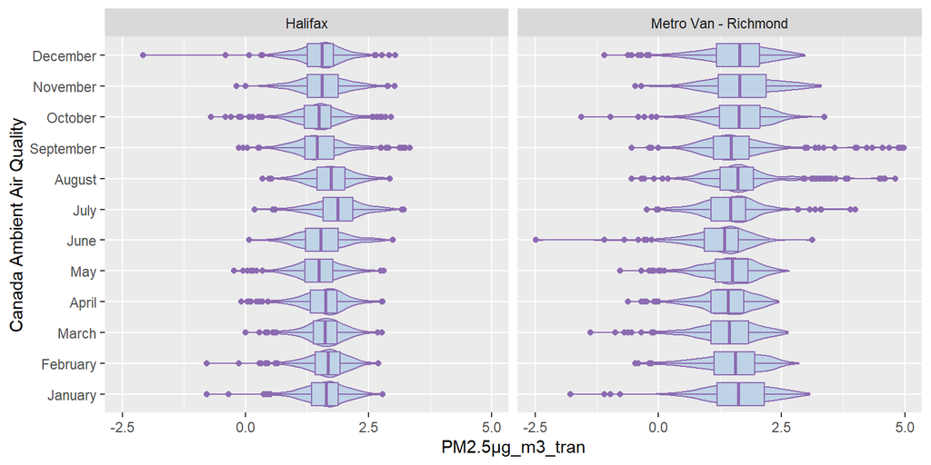

```r
ggplot(data = na.omit(filter(df.1)), aes(x =PM2.5µg_m3_tran,y=Monthly, color = City))+geom_violin(na.rm=TRUE,color = manual.colors[4], fill= manual.colors[1] ) + geom_boxplot(na.rm=TRUE,color = manual.colors[4], fill= manual.colors[1] ) + ylab("Canada Ambient Air Quality")+facet_wrap(vars(City))
```

From the graph, we can see seasonality for the PM2.5 concentration observed in these two cities.

```r
favstats(~PM2.5µg_m3_tran|City, data = df.1)
```

| City | min | Q1 | median | Q3 | max | mean | sd | n | missing |
| --- | --- | --- | --- | --- | --- | --- | --- | --- | --- |
| Halifax | -2.079442 | 1.299292 | 1.601063 | 1.890850 | 3.339616 | 1.588349 | 0.4733221 | 6097 | 0 |
| Metro Van - Richmond | -2.485307 | 1.139434 | 1.522419 | 1.897125 | 4.975871 | 1.514514 | 0.6319059 | 7590 | 0 |

## 1.7 Hypothesis Testing

#### 1.7.0.1 Difference between Standard Deviations

##### 1.7.0.1.1 To verify if there is a significant relationship between the two cities’ PM2.5 observed concentrations.

$$\begin{eqnarray}
{\rm H}_{0}& : &\text{There is no significant relationship
between two cities PM2.5} \hspace{0.2in} \sigma_{PM2.5Richmond} \:=\:
\sigma_{PM2.5Halifax} \\
{\rm H}_{A}& : & \text{There is significant relationship between
two cities PM2.5} \hspace{0.2in} \sigma_{PM2.5Richmond} \:ne\:
\sigma_{PM2.5Halifax} \
\end{eqnarray}$$

```r
diffp = (favstats(~PM2.5µg_m3|City, data = df.1)[2,])$sd - (favstats(~PM2.5µg_m3|City, data =  df.1)[1,])$sd
diffp
```

```
## [1] 3.479244
```

```r
NP = 15000
Richmond.m = numeric(NP)
Halifax.m = numeric(NP)
outcome = numeric(NP)
for (i in 1:NP)
{
  result = sample(13687, 7590, replace = FALSE)
  Richmond.m[i] = sd(df.1$PM2.5µg_m3[result])
  Halifax.m[i] = sd(df.1$PM2.5µg_m3[-result])
  outcome[i] = Richmond.m[i] - Halifax.m[i]
}
df.11 = data.frame(Richmond.m,Halifax.m,outcome)
head(df.11,2)
```

|  | Richmond.m | Halifax.m | outcome |
| --- | --- | --- | --- |
| 1 | 4.959428 | 4.951252 | 0.008176693 |
| 2 | 5.130040 | 4.729469 | 0.400570613 |

Standard deviation difference distribution and verifying normality condition:

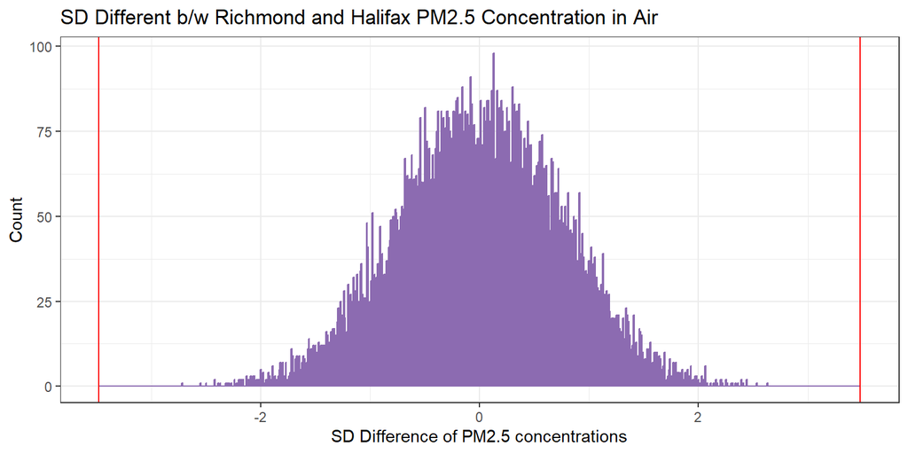

```r
ggplot(data = df.11, aes(x = outcome))+geom_histogram(binwidth = 0.01,color = manual.colors[4], fill= manual.colors[1])+ theme_bw()+xlab("SD Difference of PM2.5 concentrations")+ylab("Count")+ggtitle("SD Different b/w Richmond and Halifax PM2.5 Concentration in Air")+geom_vline(xintercept = diffp, col = "red")+geom_vline(xintercept = -diffp, col = "red")
```

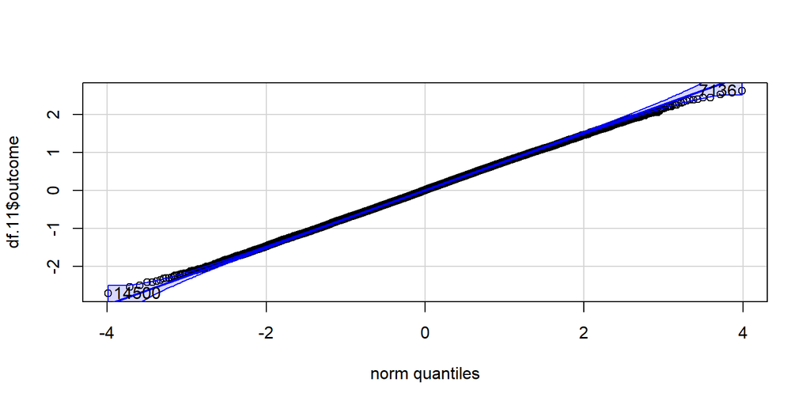

```
## [1] 14500  7136
```

```r
qqPlot(df.11$outcome)
```

Computing the $ P-value $ to verify the null hypothesis.

```r
(sum(outcome >= diffp)+sum(outcome < -1* diffp))/NP
```

```
## [1] 0
```

```r
qdata(~outcome, c(0.025,0.975), data = df.11)
```

```
##      2.5%     97.5%
## -1.436816  1.433272
```

Interpretation: Observed P-value for the permutation test is less than $\alpha=$ 0.05. It states that assuming the null hypothesis is true, the change of observing the same value is very less likely to happen. Hence null hypothesis is rejected in favor of the alternative hypothesis. Thus, there is a signification difference of their standard deviations.

To verify the mean difference between the two cities observed Pm2.5 concentrations.:

```r
t.test(PM2.5µg_m3_tran~City, data = df.1,conf.level = 0.95, var.equal=FALSE,alternative="two.sided")
```

```
##
##  Welch Two Sample t-test
##
## data:  PM2.5µg_m3_tran by City
## t = 7.811, df = 13620, p-value = 6.089e-15
## alternative hypothesis: true difference in means between group Halifax and group Metro Van - Richmond is not equal to 0
## 95 percent confidence interval:
##  0.05530630 0.09236365
## sample estimates:
##              mean in group Halifax mean in group Metro Van - Richmond
##                           1.588349                           1.514514
```

Interpretation: Observed P-value for the t-testis less than $\alpha$ = 0.05. P-value 0.000000000000006089 < 0.05 suggests that the observe test statistics $t_{obs}$ = 7.811. It states that assuming the null hypothesis is true, the change of observing the same value is very less likely to happen. Hence null hypothesis is rejected in favor of the alternative hypothesis. Thus, there is a signification difference in the mean concentration of PM2.5 in these two cities.

$$0.05530630\:\le\: X \:\le 0.09236365$$

### 1.7.1 Location based Air quality analysis between Cities.(Air_quality ~City)

$$\begin{eqnarray}
{\rm H}_{0}& : &\text{Richmond and Halifax air quality is
independent}\\
{\rm H}_{A}& : & \text{Richmond and Halifax air quality is
dependent}
\end{eqnarray}$$

```r
bivpm2.5 = tally(~Air_Quality+City , margins=TRUE, data=df.1)
bivpm2.5
```

```
##            City
## Air_Quality Halifax Metro Van - Richmond Total
##   Good         5919                 7206 13125
##   Moderate      178                  358   536
##   Unhealthy       0                   26    26
##   Total        6097                 7590 13687
```

```r
xchisq.test(bivpm2.5, correct=FALSE)
```

```
##
##  Pearson's Chi-squared test
##
## data:  x
## X-squared = 50.388, df = 6, p-value = 3.93e-09
##
##   5919.00    7206.00   13125.00
## ( 5846.65) ( 7278.35) (13125.00)
## [ 0.90]  [ 0.72]  [ 0.00]
## < 0.95>  <-0.85>  < 0.00>
##
##    178.00     358.00     536.00
## (  238.77) (  297.23) (  536.00)
## [15.47]  [12.42]  [ 0.00]
## <-3.93>  < 3.52>  < 0.00>
##
##      0.00      26.00      26.00
## (   11.58) (   14.42) (   26.00)
## [11.58]  [ 9.30]  [ 0.00]
## <-3.40>  < 3.05>  < 0.00>
##
##   6097.00    7590.00   13687.00
## ( 6097.00) ( 7590.00) (13687.00)
## [ 0.00]  [ 0.00]  [ 0.00]
## < 0.00>  < 0.00>  < 0.00>
##
## key:
##  observed
##  (expected)
##  [contribution to X-squared]
##  <Pearson residual>
```

#### 1.7.1.1 To analysed the variance of Pm2.5 concentration for the past 10 years

$$Y_{PM2.5} = A + (B* X_{Year})+ e_{i} \hspace{0.5in}$$
$$\begin{eqnarray}
{\rm H}_{0}& : & B =0\:\: \text{PM2.5µg/m3 cannot be expressed
as linear funtion of Year}\\
{\rm H}_{A}& : & B\ne 0\:\: \text{PM2.5µg/m3 can be expressed as
linear funtion of Year}
\end{eqnarray}$$

```r
df.bc = filter(df.1, City == "Metro Van - Richmond")
df.NS = filter(df.1, City == "Halifax")
one1 = aov(PM2.5µg_m3_tran~Year, data = df.bc)
summary(one1)
```

```
##               Df Sum Sq Mean Sq F value Pr(>F)
## Year          10  171.8  17.180   45.55 <2e-16 ***
## Residuals   7579 2858.5   0.377
## ---
## Signif. codes:  0 '***' 0.001 '**' 0.01 '*' 0.05 '.' 0.1 ' ' 1
```

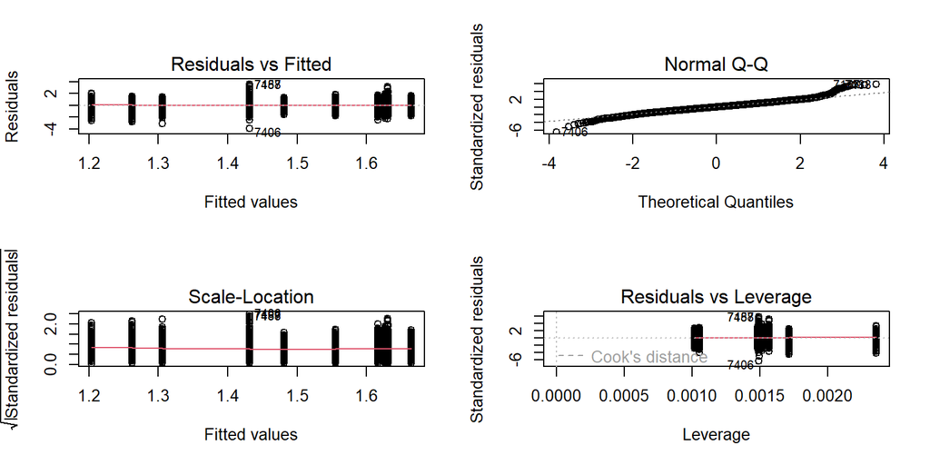

```r
par(mfrow=c(2,2))
plot(one1)  # Richmond
```

```r
one2 = aov(PM2.5µg_m3_tran~Year, data = df.NS)
summary(one2)
```

```
##               Df Sum Sq Mean Sq F value Pr(>F)
## Year          10   60.1   6.010   28.01 <2e-16 ***
## Residuals   6086 1305.6   0.215
## ---
## Signif. codes:  0 '***' 0.001 '**' 0.01 '*' 0.05 '.' 0.1 ' ' 1
```

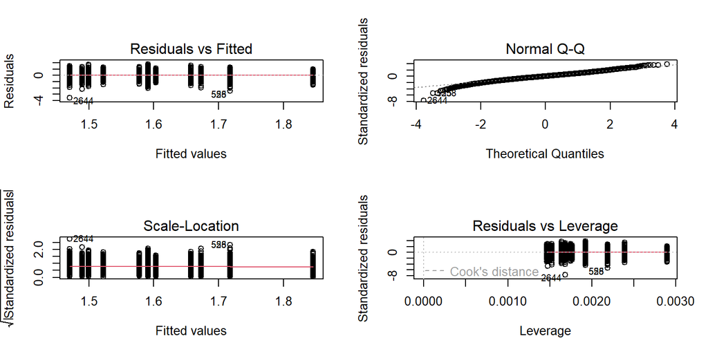

```r
par(mfrow=c(2,2))
plot(one2) # Halifax
```

The diagnostic plots show residuals:

In the Residuals, vs Fitted for both cities displayed above the horizontal line, without distinct patterns, is indicates that they had a linear relationship. Normal Q-Q plots state residuals are normally distributed. Though there is little deviation at the end due to outliers. In the Scale-Location plot, we can see the homoscedasticity of the variance of the residuals. A horizontal line with equally spread points